# Assignment 2: Data visualization

Tamas Nagy

You will have to create 3 plots based on the datasets and instructions detailed below. You will find the plots themeselves in the `assignments/assignment_2_plots`. Your task is to write the code that will reproduce the plots as closely as possible.

# Skills needed to solve this assignment

- Using R and RStudio, reading data
- Reporting using RMarkdown
- Using Git and Github (for submitting the task)
- Data manipulation (e.g. dplyr, tidyr), and working with factors (forcats)
- Data visuzlization (ggplot2)

## Task 1: Climbing expeditions

```
## ---- Compiling #TidyTuesday Information for 2020-09-22 ----
## --- There are 3 files available ---
##
##
## ── Downloading files ───────────────────────────────────────────────────────────
##
##   1 of 3: "peaks.csv"
##   2 of 3: "members.csv"
##   3 of 3: "expeditions.csv"
```

```
## # A tibble: 6 × 16
##   expedition_id peak_id peak_name     year season basecamp_date highpoint_date
##   <chr>         <chr>   <chr>        <dbl> <chr>  <date>        <date>
## 1 ANN260101     ANN2    Annapurna II  1960 Spring 1960-03-15    1960-05-17
## 2 ANN269301     ANN2    Annapurna II  1969 Autumn 1969-09-25    1969-10-22
## 3 ANN273101     ANN2    Annapurna II  1973 Spring 1973-03-16    1973-05-06
## 4 ANN278301     ANN2    Annapurna II  1978 Autumn 1978-09-08    1978-10-02
## 5 ANN279301     ANN2    Annapurna II  1979 Autumn NA            1979-10-18
## 6 ANN280101     ANN2    Annapurna II  1980 Spring 1980-03-25    1980-04-24
## # ℹ 9 more variables: termination_date <date>, termination_reason <chr>,
## #   highpoint_metres <dbl>, members <dbl>, member_deaths <dbl>,
## #   hired_staff <dbl>, hired_staff_deaths <dbl>, oxygen_used <lgl>,
## #   trekking_agency <chr>
```

```
## [1] 3351
```

```
## A szükséges csomag betöltődik: viridisLite
```

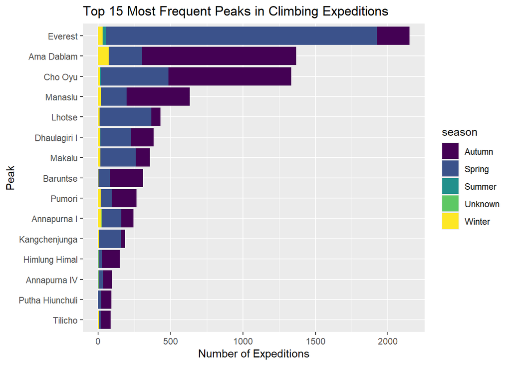

[output not shown]

[output cut: 250 more lines]

[output not shown]

[output not shown]

## Task 2: PhDs awarded

The 2019-02-19 TidyTueday dataset is about phd-s awarded by year and field. There is only one dataset, it is called `phd_by_field`. Reproduce the plot below!

Notes:

- First you have to aggregate the data to count all phd-s by broad fields.
- To make the x axis breaks pretty, use `scales::pretty_breaks()`, to make the y axis labels comma formatted, use `scales::comma_format()`.
- The line size is 1.2, the colors are from the brewer “Dark2” palette. The theme is set to minimal.

```
##
## Kapcsolódás csomaghoz: 'scales'
```

```
## ---- Compiling #TidyTuesday Information for 2019-02-19 ----
## --- There is 1 file available ---
##
##
## ── Downloading files ───────────────────────────────────────────────────────────
##
##   1 of 1: "phd_by_field.csv"
```

```
## # A tibble: 6 × 5
##   broad_field   major_field                                 field    year n_phds
##   <chr>         <chr>                                       <chr>   <dbl>  <dbl>
## 1 Life sciences Agricultural sciences and natural resources Agricu…  2008    111
## 2 Life sciences Agricultural sciences and natural resources Agricu…  2008     28
## 3 Life sciences Agricultural sciences and natural resources Agricu…  2008      3
## 4 Life sciences Agricultural sciences and natural resources Agrono…  2008     68
## 5 Life sciences Agricultural sciences and natural resources Animal…  2008     41
## 6 Life sciences Agricultural sciences and natural resources Animal…  2008     18
```

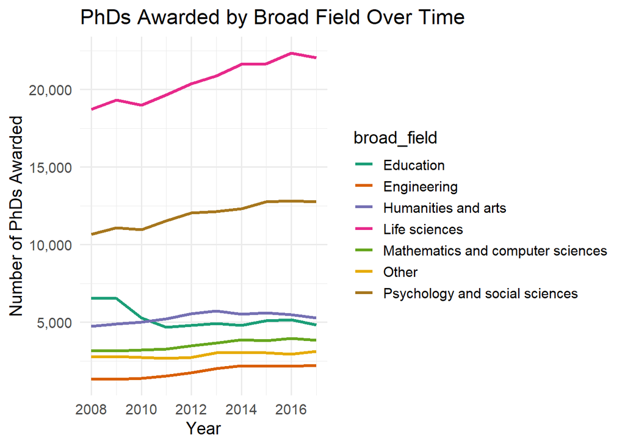

## Task 3: Commute in the US

The 2019-11-05 TidyTueday dataset is about commuting to work in each city in the US by bike or on foot. There is only one dataset, it is called `commute`. Reproduce the plot below!

Notes:

- First you have to aggregate the data to count all commutes by state.
- Both axis scales are log transformed and the labels comma formatted, using `scales::comma_format()`
- The point size is 2, . The theme is set to light.

```
## ---- Compiling #TidyTuesday Information for 2019-11-05 ----
## --- There is 1 file available ---
##
##
## ── Downloading files ───────────────────────────────────────────────────────────
##
##   1 of 1: "commute.csv"
```

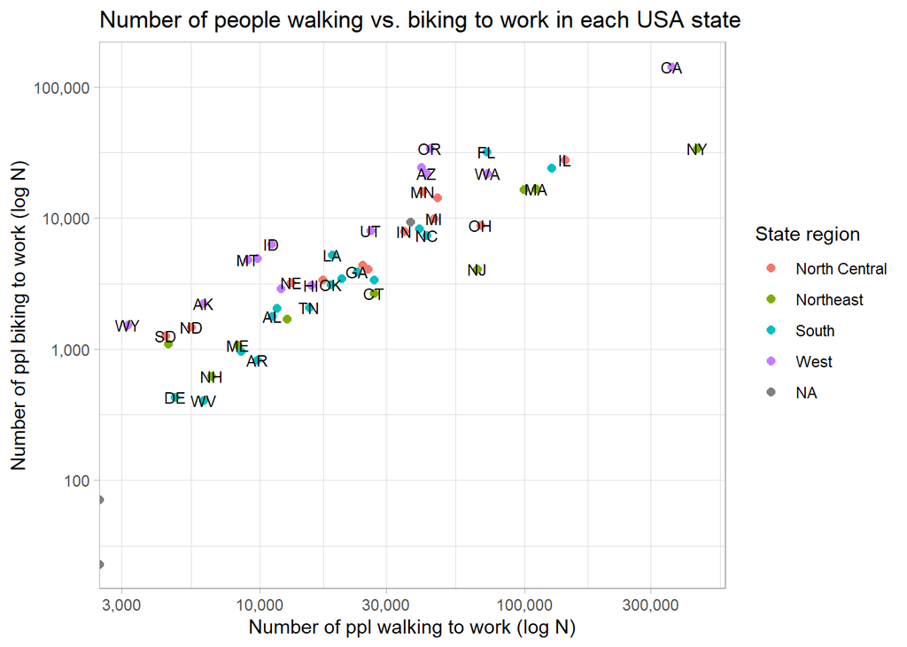